# NBA Data Exploration and Predictive Modeling

By: Logan Kerr, Eric Lu, Jeffrey Wang, Annie Yang

Final Project for CS109 Fall 2013: [Project's Github repo](https://github.com/yanann/MarchMadness)

### Overview and Motivation

The movie Moneyball helped raise public awareness of sabermetrics, which uses mathematical and statistical analysis of baseball records to predict future game outcomes. That said, sabermetrics is only one of many methodologies for applying statistics to sports– APBRmetrics, the basketball equivalent of sabermetrics, has proved to be a robust framework for predicting player and team stats. As die-hard NBA fans, our team was interested in seeing how effective the APBRmetrics were against simpler, more "brute force" metrics. In addition, we were interested in seeing how accurate models can be in predicting basketball games, which are notoriously volatile due to the close score margins.

Our team has applied APBRmetrics and simple scoring metrics to form various models for predicting game outcomes. Applying these metrics to historical game and player data from the past few years, we predicted and visualized the NBA Playoffs, verifying our results against the actual playoff outcome. We also generated playoff brackets for the 2013-2014 season (henceworth referred to as the 2014 season; 2012-2013 season will be referred to as the 2013 season, and so on).

### Related Works and References

http://www.sonicscentral.com/statsite.html (GO SONICS!).

Basketball on Paper by Dean Oliver

http://www.basketballprospectus.com/

All data were pulled from: http://www.basketball-reference.com/

### Initial Questions

What are the factors (scores per game, assists, turnovers, etc.) that are most predictive of the outcome of a game?

How well do well-known APBRmetrics stack up against simpler models that only examine 1-2 factors?

How often do team rankings change and how drastically do they change from year to year? Are there any sudden changes (i.e. dropping from first seed to last seed)? If so, can our models capture these unexpected changes? If not, what are some factors that could be causing these changes?

What do the playoff brackets look like for the 2013-2014 season?

### Outline of the Notebook

1. Data Scraping: 2008-2014
   1. Final Results of Regular Games
   2. Individual Player Data
2. Data Exploration
3. Simple Model: Frequentist Approach
   1. Baseline Score Model
   2. Adjustments to Score Model: Changing the Starting Lineup
   3. Adjustments to Score Model: Taking into consideration teams' historical win/loss margins
   4. Adjustments to the Score Model: Taking into consideration of player interaction (assists, turnovers, offensive rebounds)
4. APBRmetric Model: Bayasian Approach
   1. Offensive Rating Model
   2. Adjustment to Offensive Rating Model: Accounting for Assists
5. Game Scores Model
   1. Adjustment to Offensive Rating Model: Accounting for teamwork, offense, and defense using Game Score
   2. Visualizing team ranking from 2009-2013
6. Bracket Building for 2014
   1. Building the seeds
   2. Simulating the playoffs (**NOTE: Due to complications with bokeh, visualization code is saved in a separate file. Only screenshots will be shown here**)

# Data Scraping

Our models will be based on both individual player statistics per game from 2008-2014 and on the final results of regular season games from basketball-reference.com. The following code are general functions that can retrieve and format the HTML tables from basketball-reference.com. The code turns the HTML table into BeautifulSoup objects, then reconstructed the table into a pandas DataFrame, and finally wrote the table into a csv file.

Let us first retrieve final game results on a yearly basis and write it to a csv file.

Our code scrapes pages such as http://www.basketball-reference.com/leagues/NBA_2014_games.html for each year between 2008 and 2014.

Now, let us retrieve individual player data per game on a yearly basis from 2008-2014.

Our code starts with the page: http://www.basketball-reference.com/players/ . From this page, we scrape the URL suffixes that reference to pages containing links to the pages for individual players whose last name start with the same letter. For example, if we wanted to find all players whose last name start with "A", we would scrape the previously mentioned page to find the URL suffix "players/a/". We take this suffix and construct the URL string http://www.basketball-reference.com/players/a/ to access the page that contains links to the pages of individual players whose last name start with "A".

Then, the player directory page, we scrape for the URL construct of each individual players' page. For example, Alaa Abdelnaby's personal player page has the URL construct "/players/a/abdelal01.html". We scrape this information and use it to construct the URL string http://www.basketball-reference.com/players/a/abdelal01.html

We will ONLY look at currently active players, which are bolded in the player dictionary page, mainly due to performance issues.

# Data Exploration

In this section, we will take a look at some interesting game metrics such as average points per game and three point shots (also known as field goals).

```
<class 'pandas.core.frame.DataFrame'>
RangeIndex: 113108 entries, 0 to 113107
Data columns (total 31 columns):
Rk      113108 non-null int64
G       113108 non-null int64
Date    113108 non-null object
Age     113108 non-null object
Tm      113108 non-null object
N       113108 non-null object
Opp     113108 non-null object
N.1     113108 non-null object
GS      113108 non-null int64
MP      113108 non-null object
FG      113108 non-null int64
FGA     113108 non-null int64
FG%     113108 non-null object
3P      113108 non-null int64
3PA     113108 non-null int64
3P%     113108 non-null object
FT      113108 non-null int64
FTA     113108 non-null int64
FT%     113108 non-null object
ORB     113108 non-null int64
DRB     113108 non-null int64
TRB     113108 non-null int64
AST     113108 non-null int64
STL     113108 non-null int64
BLK     113108 non-null int64
TOV     113108 non-null int64
PF      113108 non-null int64
PTS     113108 non-null int64
GmSc    113108 non-null float64
+/-     113108 non-null object
name    113108 non-null object
dtypes: float64(1), int64(18), object(12)
memory usage: 26.8+ MB
None
                Date Visitor/Neutral  PTS Home/Neutral  PTS.1
0  Tue, Oct 30, 2012             WAS   84          CLE     94
1  Tue, Oct 30, 2012             DAL   99          LAL     91
2  Tue, Oct 30, 2012             BOS  107          MIA    120
3  Wed, Oct 31, 2012             SAC   87          CHI     93
4  Wed, Oct 31, 2012             HOU  105          DET     96
```

```
Total Active Players: 444
Total Active Teams: 30
First date of season: 2012-10-30
Last date of season: 2013-04-17
```

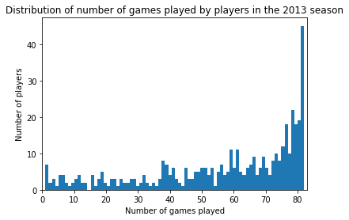

```
Number of players who played all 82 regular season games: 28
```

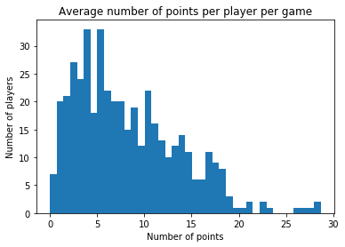

[output not shown]

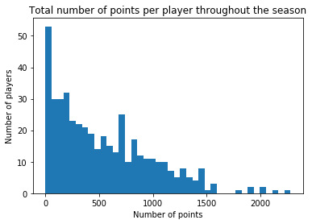

[output not shown]

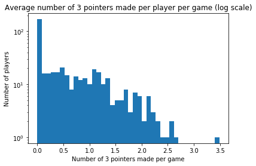

[output not shown]

What's the correlation between three point shooting and high scorers? Do high scorers in the NBA take many three pointers?

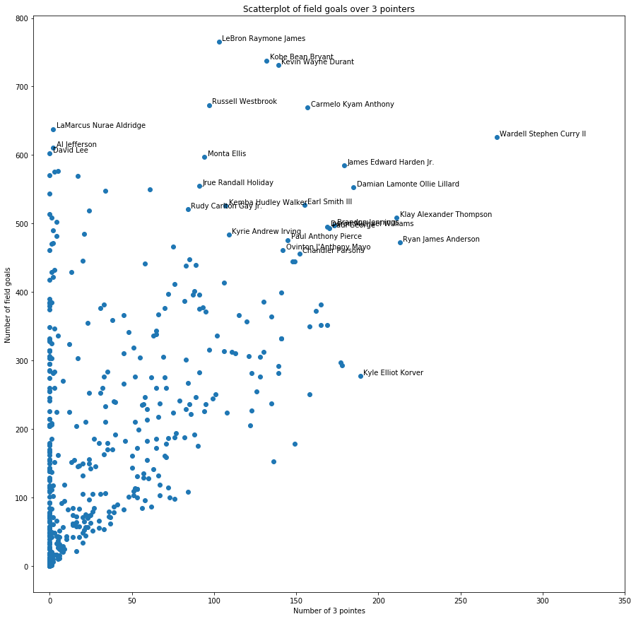

We can see that the high scoring players from before leverage a good balance of field goals and 3 pointers. Stephen Curry is a huge outlier, shooting a high number of 3 pointers as well as a relatively high number of field goals. It's very interesting to look at outlying players like LaMarcus Aldridge and David Lee, who shoot a high number of shots from the paint, and Kyle Korver, who is known for his ability to shoot 3s. Super stars like Lebron James and Kobe Bryant, of course, shoot a high number of both types of shots.

A new trend in the NBA is the idea of the "3 and D" guy - a player who plays solid defense, and on offense clears out to the wing or the outside of the floor, thus spacing out the floor and allowing more offensively talented players to get into the paint. The 3 and D guy often shoots many threes but also has a high defensive rating when he's on the floor. To see a ranking of these players, we can examine the total number of 3 pointers made, and also the total numbers of steals as well as their +/- rating. The +/- rating is a measurement of the player's contribution when they are on the floor. Thus, a highly defensive player would make the intangible contribution to their team when they are on the floor.

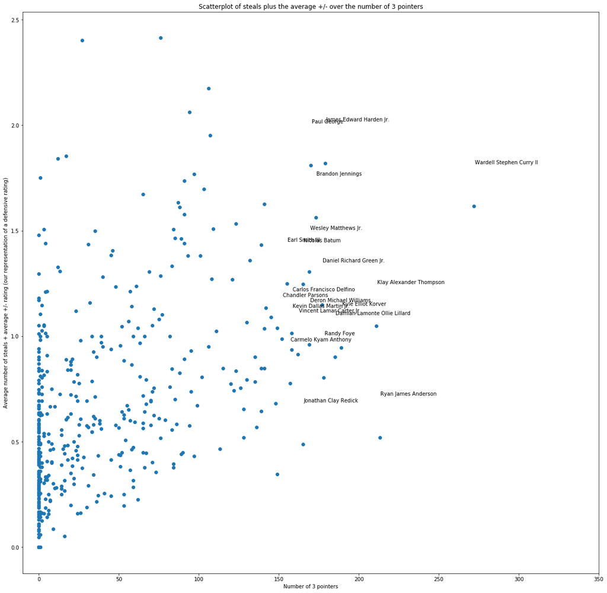

```
                            07-08  08-09  09-10  10-11  11-12  12-13
Aaron Jamal Crawford          967    781    708   1077    837   1255
Aaron Michael Gray            556    332    672    129    191    119
Al Jefferson                  394    341    944   1528   1170   1391
Albert Harrington             662   1090   1939    765    910     51
Aleksandar Pavlovic           416    814    743     76    120    103
Alfred Joel Horford           951    715    746   1178    136   1289
Amar'e Carsares Stoudemire    782    534    693   1971    823    413
Amir Jalla Johnson            696    450   1577    688    452    813
Anderson Franca Varejao       277    857    876    282    271    353
Andray Blatche                584    983    724   1076    221    843
Andre Lloyd Miller           1242    488    609   1029    639    786
Andre Tyler Iguodala          268   1510    636    945    771   1038
Andrea Bargnani               881    904    970   1414    603    443
Andrew Melvin Gooden          698    265    350    396    766     52
Andrew Michael Bogut          424    934    780    830    136    186
Andris Biedrins              1379    427    468    294     79     24
```

Below we will set up the plot for parallel coordinates, which will allow us to look at the production of the above scoreers over the last few seasons.

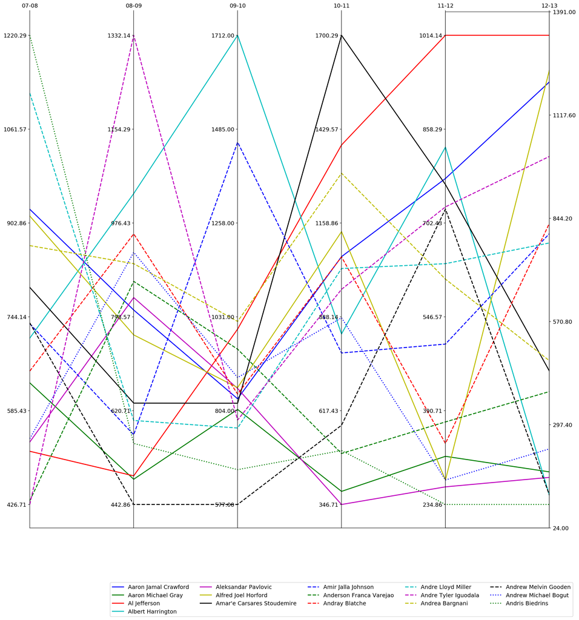

# Frequentist Score-Based Model

In this section, we experimented with two frequentist methods of predicting a given team's probability of winning/losing a game. Win/Loss probabilities were calculated using the sum of each team's starting five players' historical points-per-game.

For our first method, we fitted a statistical distribution onto the historical points-per-game data for individual players. Baseline predictions were made by sampling from the resulting fitted distributions. The second method involved creating a bootstrap sampling of our historical points-per-game data. In this case, our baseline was the average of a random sampling across the starting five players for each team.

From these baseline predictions, we made adjustments to our prediction using the following variables:

1. Historical win/loss margins for team X vs. team Y We computed the win/loss margins for each game played by team X against team Y. Next, we averaged a random sampling of these margins to create a predictive variable for team X.
2. Individual player factors for team X vs team Y First, we took a random sample of a given player's assists-per-game/turnovers-per-game/offensive rebounds-per-game. Next, we repeated this process for the starting five players of each team, adding up the assists-per-game/turnovers-per-game/offensive rebounds-per-game for each group of five to derive baseline team values. Finally, we subtracted each of team X's variables from the corresponding variables of team Y to find the advantage/disadvantage for team X as predicted by each of the given variables.

### Distribution Model

To create our distribution model, first, we must determine which distribution best fit our data. To do so, we ran a Kolmogorov-Smirnov test on popular distributions within the scipy library that, at first glance of the histogram above, appears to fit our the total points distribution for all players.

```
norm            p: 0.0                   D: 0.212225573233  Param: (10.592990769883651, 8.1548512899035153)
beta            p: 0.0                   D: 0.244794626761  Param: (0.51329209285243838, 3.0646332259874867, -5.2087734171371121e-28, 101.9807016282769)
chi             p: 3.97459842816e-14     D: 0.179202353537  Param: (0.65588454914638661, -1.3244418572842142e-28, 16.393606770949582)
chi2            p: 0.0                   D: 0.322425374041  Param: (1.2113136594625686, -3.2870350679168357e-19, 6.1003841212902383)
expon           p: 6.1017402464e-08      D: 0.132854855099  Param: (-4.8302310515885004e-10, 10.592961042135162)
fatiguelife     p: 1.82217489653e-06     D: 0.119116336222  Param: (0.56512361013922008, -4.9258064921388396, 13.374680004236485)
f               p: 0.0                   D: 0.464598931285  Param: (1.3720826005299152, 1.0139810321961984, -3.5462762386363132e-30, 1.5685362728800558)
```

### Bootstrap Model

Now, let us create a model for bootstrap sampling. For each matchup in 2013, we will find each team's starting player's historical points scored per game and store it in a dictionary. Later on, our actual sampling code will randomly select from this historical data for each player on the starting lineup of a team.

```
[26, 23, 20, 23, 20, 21, 20, 38, 30, 27, 21, 28, 30, 23, 21, 26, 31, 24, 27, 31, 23, 22, 24, 30, 29, 27, 35, 26, 36, 32, 30, 24, 22, 15, 20, 32, 25, 39, 31, 23, 34, 24, 28, 30, 31, 32, 30, 32, 30, 39, 24, 26, 16, 28, 40, 18, 29, 20, 26, 25, 13, 15, 27, 28, 22, 37, 25, 29, 32, 24, 32, 36, 27, 28, 20,…
```

### Sampling

Next, we will create our sampling models. For both models, the steps are the same as follows:

1. Determine the starting lineup (5 players) for a given match. The information on the starting lineup for any given game is not readily available on basketball-reference.com. Though we could have created a scrapping algorithm and piece together the retrieved information, we believe that we can obtain equally accurate results by making a few assumptions to determine which players are part of the starting lineup. For this first model, the starting lineup will be composed of the 5 players with the highest historical average score per game. Our logic behind this assumption is that players who have historically been high scorers are more likely to be chosen to be part of the startling lineup.
2. Iterate through all of the match-ups for 2013. For each match-up, predict the scores of each team by sampling from the fitted distribution or historical scores of individual players in the starting lineup

```
['Monta Ellis' 'Aaron Jamal Crawford' 'Corey Antoine Maggette'
 'Wardell Stephen Curry II' 'David Lee']
```

```
46.1344327358
105.789366774
71
```

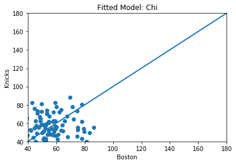

```
Probability of BOS Win: 0.55
```

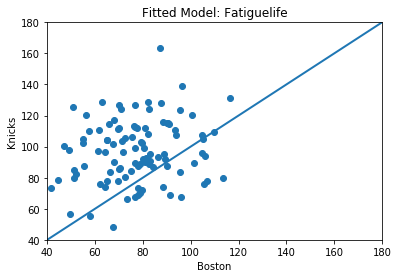

```
Probability of BOS Win: 0.21
```

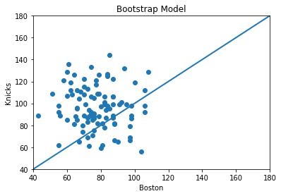

```
Probability of BOS Win: 0.2
```

We will now test our models against the results from the 2013 season. To compare the performance of our model against actual 2013 results, we will examine 2 metrics, percentage of games that we correctly predicted and the predicted win percentage for each team. For the former metric, in addition to displaying the percentage of games that we correctly predicted, we will also break down the accuracy in terms of percentage of close games predicted and percentage of blowout games predicted. For the later metric, we will display a graph plotting the predicted win percentage per team against the actual win percentage per team.

```
{'ATL': 0.5365853658536586, 'BKN': 0.5975609756097561, 'BOS': 0.5, 'CHA': 0.25609756097560976, 'CHI': 0.5487804878048781, 'CLE': 0.2926829268292683, 'DAL': 0.5, 'DEN': 0.6951219512195121, 'DET': 0.35365853658536583, 'GSW': 0.573170731707317, 'HOU': 0.5487804878048781, 'IND': 0.5975609756097561, 'LAC…
```

```
(1.0, 1.0, 1.0)
```

```
chi Model
Overall, the model correctly predicts: 52.24% of game outcomes
Overall, the model correctly predicts: 55.26% of close outcomes
Overall, the model correctly predicts: 52.45% of blowout outcomes
```

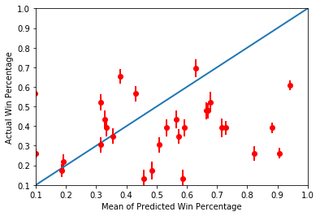

```
fatiguelife Model
Overall, the model correctly predicts: 57.85% of game outcomes
Overall, the model correctly predicts: 56.84% of close outcomes
Overall, the model correctly predicts: 59.70% of blowout outcomes
```

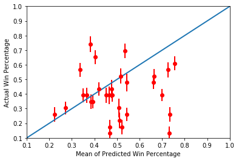

```
Bootstrap Model
Overall, the model correctly predicts: 57.04% of game outcomes
Overall, the model correctly predicts: 54.74% of close outcomes
Overall, the model correctly predicts: 59.53% of blowout outcomes
```

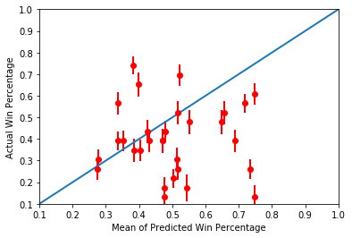

This accuracy is emphasized by the graphs above. Here, we are plotting the mean predicted win percentage on the x-axis against the actual win percentage on the y-axis, with error bars illustrating standard deviation within the predicted win percentages. The x=y blue line represents a perfectly calibrated system where all the mean predictions are equal to the actual win percentages. Thus, the closer our results are to the blue line, the higher the chance that our data is overfitted; the further away they are, the higher the chance that they are underfit.

In comparing the fitted models to the bootstrap model, we can see that there is not much difference between the two models. The fitted models do appear to be slightly more overfitted with more points lying directly on the blue line. They also appear to have smaller error bars than the bootstrap model.

### Adjustments to the Starting Lineup

We will now test other variations of this model by changing how the starting lineup is determined. First, instead of creating the starting lineup from the top average scorers, we will create the starting lineup from the top scorers of 2013.

```
chi Model
Overall, the model correctly predicts: 54.92% of game outcomes
Overall, the model correctly predicts: 54.74% of close outcomes
Overall, the model correctly predicts: 56.32% of blowout outcomes
```

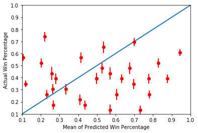

```
fatiguelife Model
Overall, the model correctly predicts: 60.70% of game outcomes
Overall, the model correctly predicts: 54.74% of close outcomes
Overall, the model correctly predicts: 64.92% of blowout outcomes
```

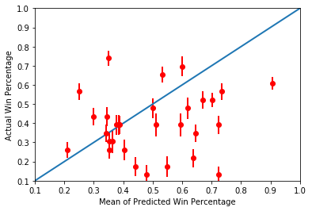

```
Bootstrap Model
Overall, the model correctly predicts: 59.48% of game outcomes
Overall, the model correctly predicts: 55.79% of close outcomes
Overall, the model correctly predicts: 62.90% of blowout outcomes
```

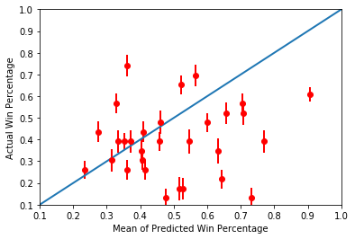

In the next iteration, we will directly base our starting lineup on minutes played in 2013. The starting five will be the players on a team who had the highest average playing time. This variation should be close in accuracy to the previous model that used highest average score in 2013 since players who scored the most were probably also on the court for the longest period of time.

```
chi Model
Overall, the model correctly predicts: 55.98% of game outcomes
Overall, the model correctly predicts: 56.84% of close outcomes
Overall, the model correctly predicts: 56.66% of blowout outcomes
```

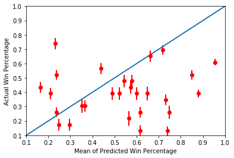

```
fatiguelife Model
Overall, the model correctly predicts: 61.03% of game outcomes
Overall, the model correctly predicts: 56.84% of close outcomes
Overall, the model correctly predicts: 64.76% of blowout outcomes
```

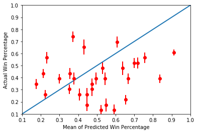

```
Bootstrap Model
Overall, the model correctly predicts: 59.80% of game outcomes
Overall, the model correctly predicts: 54.74% of close outcomes
Overall, the model correctly predicts: 63.58% of blowout outcomes
```

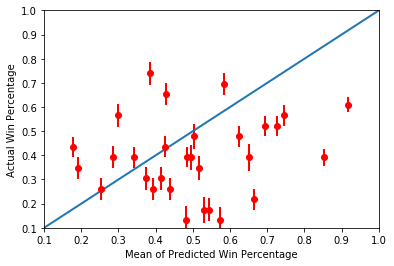

As we can see, there does not appear to be a major change in the accuracy metrics of the model which continue to hover around 60%. There is a slight change to the distribution of the results, which appear to flatten out as the points move slightly closer to the blue line.

Although there does not appear to be any major difference between using average points scored in 2013 and average minutes-played in 2013 in creating the starting lineup, we will be using the starting lineup built by average minutes-played as total court time is a more reliable indication of being part of the starting lineup. This method avoids potential corner cases where a substitute may have scored a large number of points during the few minutes they play on the court.

### Adjustments to Baseline Score Model: History Against Other Teams

As we can see above, our baseline score models, using 2013 minutes-played to determine the starting lineup, are all reasonably accurate with an overall accuracy of around 60%, higher than the 50% accuracy due to pure chance. However, our models only factor in individual players' scores and do not take into consideration interaction between teams. Some teams, while otherwise a very strong team overall, may have chronically poor performance against one team in particular whether it is because they are long-time rivals or because that particular opponent has figured the strategy behind the team's success.

```
                      Date  margins
matches
CLE,WAS  Tue, Oct 30, 2012       10
LAL,DAL  Tue, Oct 30, 2012       -8
MIA,BOS  Tue, Oct 30, 2012       13
CHI,SAC  Wed, Oct 31, 2012        6
DET,HOU  Wed, Oct 31, 2012       -9
```

```
fatiguelife Model
Overall, the model correctly predicts: 63.06% of game outcomes
Overall, the model correctly predicts: 55.26% of close outcomes
Overall, the model correctly predicts: 66.95% of blowout outcomes
```

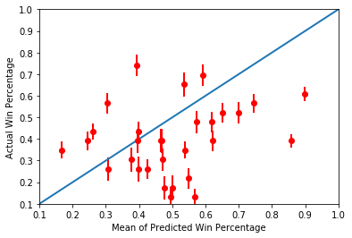

```
Bootstrap Model
Overall, the model correctly predicts: 62.25% of game outcomes
Overall, the model correctly predicts: 58.42% of close outcomes
Overall, the model correctly predicts: 65.26% of blowout outcomes
```

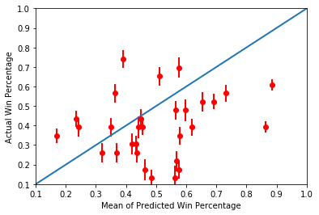

Interestingly, introducing historical margins did not significantly improve our accuracy metrics. However, looking at the graphs, sampling from historical margins appears to have introduced more variation to our results and decreased the calibration of the model; there are now less points directly on the blue line.

One possible explanation for the lack of increased accuracy is that perhaps a team does not have a consistent history against an opposing team. It could be that their win percentage against most teams, historically, amount to around 50% or, if they do have a historically low win percentage against a team, that the margins by which they lose/win is not large enough to truely impact our baseline scoring model.

Even though accounting for historical margins do not appear to have increased our accuracy, we will keep this adjustment in our models as it introduces more variability to the data and appears to be effective at preventing overfitting.

### Additional Adjustments to the model: Assists, Turnovers, and Offensive Rebounds

Now, let us introduce more variables to the model. Specifically, we will look at assists, offensive rebounds, and turnovers, the later two quoted by Dean Oliver as among the 4 most important statistics in basketball.

```
{'ATL': 0.5365853658536586, 'BKN': 0.5975609756097561, 'BOS': 0.5, 'CHA': 0.25609756097560976, 'CHI': 0.5487804878048781, 'CLE': 0.2926829268292683, 'DAL': 0.5, 'DEN': 0.6951219512195121, 'DET': 0.35365853658536583, 'GSW': 0.573170731707317, 'HOU': 0.5487804878048781, 'IND': 0.5975609756097561, 'LAC…
```

```
Bootstrap Model
Overall, the model correctly predicts: 67.37% of game outcomes
Overall, the model correctly predicts: 62.63% of close outcomes
Overall, the model correctly predicts: 70.66% of blowout outcomes
```

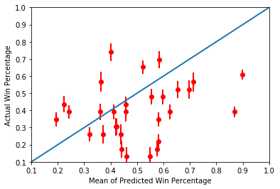

```
Bootstrap Model
Overall, the model correctly predicts: 66.31% of game outcomes
Overall, the model correctly predicts: 57.89% of close outcomes
Overall, the model correctly predicts: 70.15% of blowout outcomes
```

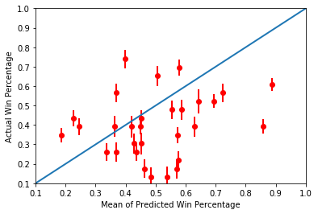

```
Bootstrap Model
Overall, the model correctly predicts: 66.48% of game outcomes
Overall, the model correctly predicts: 60.00% of close outcomes
Overall, the model correctly predicts: 70.49% of blowout outcomes
```

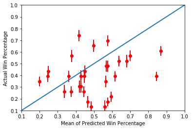

```
Bootstrap Model
Overall, the model correctly predicts: 66.23% of game outcomes
Overall, the model correctly predicts: 60.00% of close outcomes
Overall, the model correctly predicts: 69.14% of blowout outcomes
```

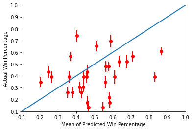